# STAT570_HW2

Oğuzhan Aydın 236111

2023-11-20

```r
library(tidyverse)
library(dplyr)
library(nycflights13)
library(ggplot2)
make_datetime_100 <- function(year, month, day, time) {
  make_datetime(year, month, day, time %/% 100, time %% 100)
}
flights_dt <- flights |>
  filter(!is.na(dep_time), !is.na(arr_time)) |>
  mutate(
    dep_time = make_datetime_100(year, month, day, dep_time),
    arr_time = make_datetime_100(year, month, day, arr_time),
    sched_dep_time = make_datetime_100(year, month, day, sched_dep_time),
    sched_arr_time = make_datetime_100(year, month, day, sched_arr_time)
  ) |>
  select(origin, dest, ends_with("delay"), ends_with("time"))
flights_dt2 <- flights_dt
```

# 17.2.4 From Other Types

By writing the following codes, we can get today’s date and the exact time for now.

```r
today()
```

```
## [1] "2023-11-21"
```

```r
now()
```

```
## [1] "2023-11-21 00:23:43 +03"
```

Additionally, by changing the time zone, we can reach the current time or specific time in any part of the world.

```r
as_datetime(now(), tz="UTC")
```

```
## [1] "2023-11-20 21:23:43 UTC"
```

```r
as_datetime(now(), tz="Europe/Istanbul")
```

```
## [1] "2023-11-21 00:23:43 +03"
```

```r
as.POSIXct(now(), tz = "CET")
```

```
## [1] "2023-11-20 22:23:43 CET"
```

```r
as.POSIXct(now(), tz = "America/New_York")
```

```
## [1] "2023-11-20 16:23:43 EST"
```

By using some mathematical operators, we can find out how many seconds later we will be at a certain time.

If we do not enter a specific date, it takes the start date as January 1, 1970.

```r
as_datetime(1)
```

```
## [1] "1970-01-01 00:00:01 UTC"
```

```r
as_datetime(60*60*60)
```

```
## [1] "1970-01-03 12:00:00 UTC"
```

```r
as_datetime(600000000)
```

```
## [1] "1989-01-05 10:40:00 UTC"
```

```r
now() + 60*60
```

```
## [1] "2023-11-21 01:23:43 +03"
```

Or, we can do it in a day basis.

```r
as_date(1) #Gün değişiyor
```

```
## [1] "1970-01-02"
```

```r
as_date(19681)
```

```
## [1] "2023-11-20"
```

If we want, we can calculate how many days have been passed between specific two dates.

```r
now()- as_datetime("2000-08-25 00:00:00")
```

```
## Time difference of 8487.891 days
```

# Date - Time Components

With various functions, it can be easily reached the year, month, day and even minutes of a time or a day.

```r
datetime <- ymd_hms(now())
year(datetime)
```

```
## [1] 2023
```

```r
#month(datetime)
#day(datetime)
#minute(datetime)
second(datetime)
```

```
## [1] 43.51832
```

By using following codes, we can find out what day of the year, month or week it is.

```r
yday(datetime)
```

```
## [1] 325
```

```r
mday(datetime)
```

```
## [1] 21
```

```r
wday(datetime)
```

```
## [1] 3
```

A leap year is a calendar year that contains an additional day compared to a common year. We can find out which years are the leap years.

```r
leap_year(2020:2024)
```

```
## [1]  TRUE FALSE FALSE FALSE  TRUE
```

The function that provides an automatic answer for those who do not know how many days are in a month:

```r
days_in_month(1:12)
```

```
## Jan Feb Mar Apr May Jun Jul Aug Sep Oct Nov Dec
##  31  28  31  30  31  30  31  31  30  31  30  31
```

## Question: How does the average departure delay vary over different months for morning (AM) and afternoon/evening (PM) flights?

```r
flights_dt2 <- flights_dt2 %>%
  mutate(am = am(dep_time),
         pm = pm(dep_time),
         month = months(dep_time, abbreviate = TRUE))

average_delay <- flights_dt2 %>%
  group_by(month, period = ifelse(am, "AM", "PM")) %>%
  summarise(avg_dep_delay = mean(dep_delay, na.rm = TRUE))
```

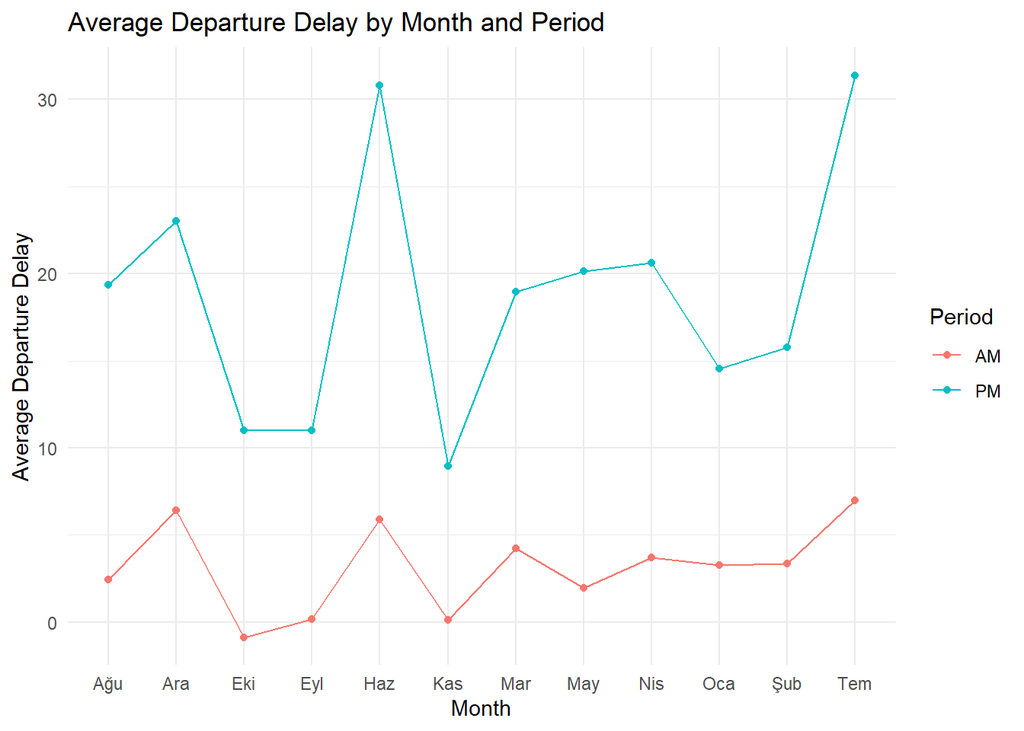

```r
ggplot(average_delay, aes(x = month, y = avg_dep_delay, group = period, color = period)) +
  geom_line() +
  geom_point() +
  labs(title = "Average Departure Delay by Month and Period",
       x = "Month",
       y = "Average Departure Delay",
       color = "Period") +
  theme_minimal()
```